# Risk Factor Analysis

## Outcome Variable

**Outcome Variable:** ever_wasted

## Predictor Variables

**Intervention Variable:** impsan

**Adjustment Set:**

- arm
- sex
- W_mage
- meducyrs
- feducyrs
- hhwealth_quart
- hfoodsec
- W_mhtcm
- W_nrooms
- W_nchldlt5
- W_parity
- impfloor
- safeh20
- delta_W_mage
- delta_meducyrs
- delta_feducyrs
- delta_hhwealth_quart
- delta_hfoodsec
- delta_W_mhtcm
- delta_W_nrooms
- delta_W_nchldlt5
- delta_W_parity
- delta_impfloor
- delta_safeh20

## Stratifying Variables

The analysis was stratified on these variable(s):

- agecat
- studyid
- country

## Data Summary

| agecat | studyid | country | impsan | ever_wasted | n_cell | n |
| --- | --- | --- | --- | --- | --- | --- |
| 0-24 months (no birth wast) | ki0047075b-MAL-ED | BANGLADESH | 1 | 0 | 157 | 242 |
| 0-24 months (no birth wast) | ki0047075b-MAL-ED | BANGLADESH | 1 | 1 | 47 | 242 |
| 0-24 months (no birth wast) | ki0047075b-MAL-ED | BANGLADESH | 0 | 0 | 28 | 242 |
| 0-24 months (no birth wast) | ki0047075b-MAL-ED | BANGLADESH | 0 | 1 | 10 | 242 |
| 0-24 months (no birth wast) | ki0047075b-MAL-ED | BRAZIL | 1 | 0 | 193 | 209 |
| 0-24 months (no birth wast) | ki0047075b-MAL-ED | BRAZIL | 1 | 1 | 12 | 209 |
| 0-24 months (no birth wast) | ki0047075b-MAL-ED | BRAZIL | 0 | 0 | 4 | 209 |
| 0-24 months (no birth wast) | ki0047075b-MAL-ED | BRAZIL | 0 | 1 | 0 | 209 |
| 0-24 months (no birth wast) | ki0047075b-MAL-ED | INDIA | 1 | 0 | 75 | 229 |
| 0-24 months (no birth wast) | ki0047075b-MAL-ED | INDIA | 1 | 1 | 30 | 229 |
| 0-24 months (no birth wast) | ki0047075b-MAL-ED | INDIA | 0 | 0 | 69 | 229 |
| 0-24 months (no birth wast) | ki0047075b-MAL-ED | INDIA | 0 | 1 | 55 | 229 |
| 0-24 months (no birth wast) | ki0047075b-MAL-ED | NEPAL | 1 | 0 | 190 | 236 |
| 0-24 months (no birth wast) | ki0047075b-MAL-ED | NEPAL | 1 | 1 | 45 | 236 |
| 0-24 months (no birth wast) | ki0047075b-MAL-ED | NEPAL | 0 | 0 | 1 | 236 |
| 0-24 months (no birth wast) | ki0047075b-MAL-ED | NEPAL | 0 | 1 | 0 | 236 |
| 0-24 months (no birth wast) | ki0047075b-MAL-ED | PERU | 1 | 0 | 59 | 263 |
| 0-24 months (no birth wast) | ki0047075b-MAL-ED | PERU | 1 | 1 | 6 | 263 |
| 0-24 months (no birth wast) | ki0047075b-MAL-ED | PERU | 0 | 0 | 184 | 263 |
| 0-24 months (no birth wast) | ki0047075b-MAL-ED | PERU | 0 | 1 | 14 | 263 |
| 0-24 months (no birth wast) | ki0047075b-MAL-ED | SOUTH AFRICA | 1 | 0 | 3 | 250 |
| 0-24 months (no birth wast) | ki0047075b-MAL-ED | SOUTH AFRICA | 1 | 1 | 1 | 250 |
| 0-24 months (no birth wast) | ki0047075b-MAL-ED | SOUTH AFRICA | 0 | 0 | 204 | 250 |
| 0-24 months (no birth wast) | ki0047075b-MAL-ED | SOUTH AFRICA | 0 | 1 | 42 | 250 |
| 0-24 months (no birth wast) | ki0047075b-MAL-ED | TANZANIA, UNITED REPUBLIC OF | 1 | 0 | 0 | 241 |
| 0-24 months (no birth wast) | ki0047075b-MAL-ED | TANZANIA, UNITED REPUBLIC OF | 1 | 1 | 0 | 241 |
| 0-24 months (no birth wast) | ki0047075b-MAL-ED | TANZANIA, UNITED REPUBLIC OF | 0 | 0 | 212 | 241 |
| 0-24 months (no birth wast) | ki0047075b-MAL-ED | TANZANIA, UNITED REPUBLIC OF | 0 | 1 | 29 | 241 |
| 0-24 months (no birth wast) | ki1017093-NIH-Birth | BANGLADESH | 1 | 0 | 180 | 602 |
| 0-24 months (no birth wast) | ki1017093-NIH-Birth | BANGLADESH | 1 | 1 | 53 | 602 |

[output cut: 174 more lines]

The following strata were considered:

- agecat: 0-24 months (no birth wast), studyid: ki0047075b-MAL-ED, country: BANGLADESH
- agecat: 0-24 months (no birth wast), studyid: ki0047075b-MAL-ED, country: BRAZIL
- agecat: 0-24 months (no birth wast), studyid: ki0047075b-MAL-ED, country: INDIA
- agecat: 0-24 months (no birth wast), studyid: ki0047075b-MAL-ED, country: NEPAL
- agecat: 0-24 months (no birth wast), studyid: ki0047075b-MAL-ED, country: PERU
- agecat: 0-24 months (no birth wast), studyid: ki0047075b-MAL-ED, country: SOUTH AFRICA
- agecat: 0-24 months (no birth wast), studyid: ki0047075b-MAL-ED, country: TANZANIA, UNITED REPUBLIC OF
- agecat: 0-24 months (no birth wast), studyid: ki1017093-NIH-Birth, country: BANGLADESH
- agecat: 0-24 months (no birth wast), studyid: ki1017093b-PROVIDE, country: BANGLADESH
- agecat: 0-24 months (no birth wast), studyid: ki1017093c-NIH-Crypto, country: BANGLADESH
- agecat: 0-24 months (no birth wast), studyid: ki1114097-CONTENT, country: PERU
- agecat: 0-24 months (no birth wast), studyid: ki1135781-COHORTS, country: GUATEMALA
- agecat: 0-24 months (no birth wast), studyid: ki1135781-COHORTS, country: INDIA
- agecat: 0-24 months (no birth wast), studyid: ki1135781-COHORTS, country: PHILIPPINES
- agecat: 0-24 months (no birth wast), studyid: ki1148112-LCNI-5, country: MALAWI
- agecat: 0-24 months (no birth wast), studyid: kiGH5241-JiVitA-3, country: BANGLADESH
- agecat: 0-24 months (no birth wast), studyid: kiGH5241-JiVitA-4, country: BANGLADESH
- agecat: 0-6 months (no birth wast), studyid: ki0047075b-MAL-ED, country: BANGLADESH
- agecat: 0-6 months (no birth wast), studyid: ki0047075b-MAL-ED, country: BRAZIL
- agecat: 0-6 months (no birth wast), studyid: ki0047075b-MAL-ED, country: INDIA
- agecat: 0-6 months (no birth wast), studyid: ki0047075b-MAL-ED, country: NEPAL
- agecat: 0-6 months (no birth wast), studyid: ki0047075b-MAL-ED, country: PERU
- agecat: 0-6 months (no birth wast), studyid: ki0047075b-MAL-ED, country: SOUTH AFRICA
- agecat: 0-6 months (no birth wast), studyid: ki0047075b-MAL-ED, country: TANZANIA, UNITED REPUBLIC OF
- agecat: 0-6 months (no birth wast), studyid: ki1017093-NIH-Birth, country: BANGLADESH
- agecat: 0-6 months (no birth wast), studyid: ki1017093b-PROVIDE, country: BANGLADESH
- agecat: 0-6 months (no birth wast), studyid: ki1017093c-NIH-Crypto, country: BANGLADESH
- agecat: 0-6 months (no birth wast), studyid: ki1114097-CONTENT, country: PERU
- agecat: 0-6 months (no birth wast), studyid: ki1135781-COHORTS, country: GUATEMALA
- agecat: 0-6 months (no birth wast), studyid: ki1135781-COHORTS, country: INDIA
- agecat: 0-6 months (no birth wast), studyid: ki1135781-COHORTS, country: PHILIPPINES
- agecat: 0-6 months (no birth wast), studyid: ki1148112-LCNI-5, country: MALAWI
- agecat: 0-6 months (no birth wast), studyid: kiGH5241-JiVitA-3, country: BANGLADESH
- agecat: 0-6 months (no birth wast), studyid: kiGH5241-JiVitA-4, country: BANGLADESH
- agecat: 6-24 months, studyid: ki0047075b-MAL-ED, country: BANGLADESH
- agecat: 6-24 months, studyid: ki0047075b-MAL-ED, country: BRAZIL
- agecat: 6-24 months, studyid: ki0047075b-MAL-ED, country: INDIA
- agecat: 6-24 months, studyid: ki0047075b-MAL-ED, country: NEPAL
- agecat: 6-24 months, studyid: ki0047075b-MAL-ED, country: PERU
- agecat: 6-24 months, studyid: ki0047075b-MAL-ED, country: SOUTH AFRICA
- agecat: 6-24 months, studyid: ki0047075b-MAL-ED, country: TANZANIA, UNITED REPUBLIC OF
- agecat: 6-24 months, studyid: ki1017093-NIH-Birth, country: BANGLADESH
- agecat: 6-24 months, studyid: ki1017093b-PROVIDE, country: BANGLADESH
- agecat: 6-24 months, studyid: ki1017093c-NIH-Crypto, country: BANGLADESH
- agecat: 6-24 months, studyid: ki1114097-CONTENT, country: PERU
- agecat: 6-24 months, studyid: ki1135781-COHORTS, country: GUATEMALA
- agecat: 6-24 months, studyid: ki1135781-COHORTS, country: INDIA
- agecat: 6-24 months, studyid: ki1135781-COHORTS, country: PHILIPPINES
- agecat: 6-24 months, studyid: ki1148112-LCNI-5, country: MALAWI
- agecat: 6-24 months, studyid: kiGH5241-JiVitA-3, country: BANGLADESH
- agecat: 6-24 months, studyid: kiGH5241-JiVitA-4, country: BANGLADESH

### Dropped Strata

Some strata were dropped due to rare outcomes:

- agecat: 0-24 months (no birth wast), studyid: ki0047075b-MAL-ED, country: BRAZIL
- agecat: 0-24 months (no birth wast), studyid: ki0047075b-MAL-ED, country: NEPAL
- agecat: 0-24 months (no birth wast), studyid: ki0047075b-MAL-ED, country: SOUTH AFRICA
- agecat: 0-24 months (no birth wast), studyid: ki0047075b-MAL-ED, country: TANZANIA, UNITED REPUBLIC OF
- agecat: 0-24 months (no birth wast), studyid: ki1114097-CONTENT, country: PERU
- agecat: 0-24 months (no birth wast), studyid: ki1148112-LCNI-5, country: MALAWI
- agecat: 0-6 months (no birth wast), studyid: ki0047075b-MAL-ED, country: BANGLADESH
- agecat: 0-6 months (no birth wast), studyid: ki0047075b-MAL-ED, country: BRAZIL
- agecat: 0-6 months (no birth wast), studyid: ki0047075b-MAL-ED, country: NEPAL
- agecat: 0-6 months (no birth wast), studyid: ki0047075b-MAL-ED, country: PERU
- agecat: 0-6 months (no birth wast), studyid: ki0047075b-MAL-ED, country: SOUTH AFRICA
- agecat: 0-6 months (no birth wast), studyid: ki0047075b-MAL-ED, country: TANZANIA, UNITED REPUBLIC OF
- agecat: 0-6 months (no birth wast), studyid: ki1017093b-PROVIDE, country: BANGLADESH
- agecat: 0-6 months (no birth wast), studyid: ki1017093c-NIH-Crypto, country: BANGLADESH
- agecat: 0-6 months (no birth wast), studyid: ki1114097-CONTENT, country: PERU
- agecat: 0-6 months (no birth wast), studyid: ki1135781-COHORTS, country: GUATEMALA
- agecat: 0-6 months (no birth wast), studyid: ki1148112-LCNI-5, country: MALAWI
- agecat: 6-24 months, studyid: ki0047075b-MAL-ED, country: BRAZIL
- agecat: 6-24 months, studyid: ki0047075b-MAL-ED, country: NEPAL
- agecat: 6-24 months, studyid: ki0047075b-MAL-ED, country: SOUTH AFRICA
- agecat: 6-24 months, studyid: ki0047075b-MAL-ED, country: TANZANIA, UNITED REPUBLIC OF
- agecat: 6-24 months, studyid: ki1114097-CONTENT, country: PERU
- agecat: 6-24 months, studyid: ki1148112-LCNI-5, country: MALAWI

## Methods Detail

We’re interested in the causal parameters $E[Y_a]$ for all values of $a \in \mathcal{A}$. These parameters represent the mean outcome if, possibly contrary to fact, we intervened to set all units to have $A=a$. Under the randomization and positivity assumptions, these are identified by the statistical parameters $\psi_a=E_W[E_{Y|A,W}(Y|A=a,W)]$. In addition, we’re interested in the mean of $Y$, $E[Y]$ under no intervention (the observed mean). We will estimate these parameters by using SuperLearner to fit the relevant likelihood factors – $E_{Y|A,W}(Y|A=a,W)$ and $p(A=a|W)$, and then updating our likelihood fit using a joint TMLE.

For unadjusted analyses ($W=\{\}$), initial likelihoods were estimated using Lrnr_glm to estimate the simple $E(Y|A)$ and Lrnr_mean to estimate $p(A)$. For adjusted analyses, a small library containing Lrnr_glmnet, Lrnr_xgboost, and Lrnr_mean was used.

Having estimated these parameters, we will then use the delta method to estimate relative risks and attributable risks relative to a prespecified baseline level of $A$.

# Results Detail

## Results Plots

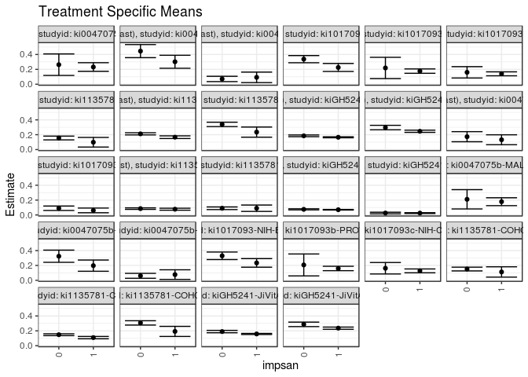

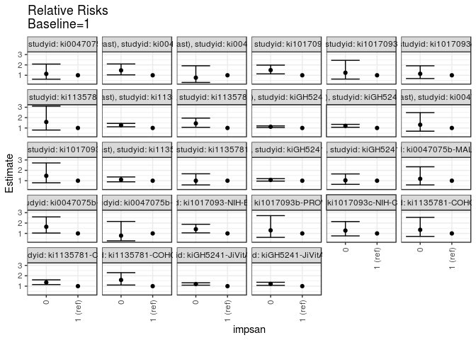

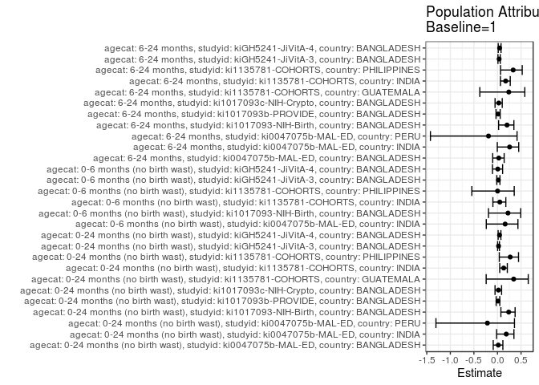

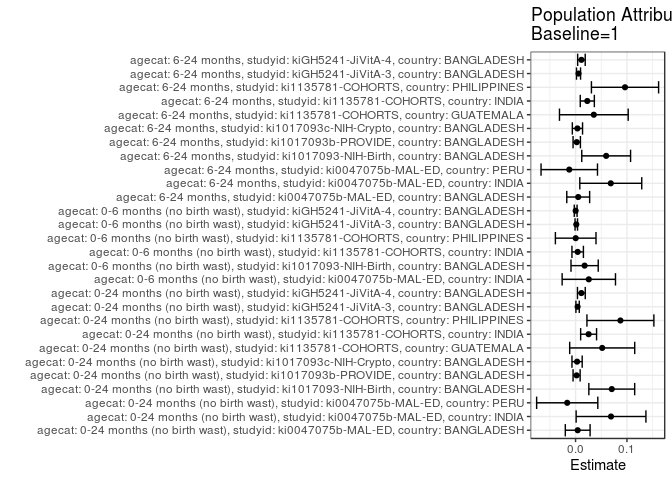

## Results Table

### Parameter: TSM

| agecat | studyid | country | intervention_level | baseline_level | estimate | ci_lower | ci_upper |
| --- | --- | --- | --- | --- | --- | --- | --- |
| 0-24 months (no birth wast) | ki0047075b-MAL-ED | BANGLADESH | 1 | NA | 0.2313982 | 0.1734189 | 0.2893776 |
| 0-24 months (no birth wast) | ki0047075b-MAL-ED | BANGLADESH | 0 | NA | 0.2626601 | 0.1180213 | 0.4072989 |
| 0-24 months (no birth wast) | ki0047075b-MAL-ED | INDIA | 1 | NA | 0.3021951 | 0.2148893 | 0.3895010 |
| 0-24 months (no birth wast) | ki0047075b-MAL-ED | INDIA | 0 | NA | 0.4452434 | 0.3572932 | 0.5331936 |
| 0-24 months (no birth wast) | ki0047075b-MAL-ED | PERU | 1 | NA | 0.0923077 | 0.0218048 | 0.1628106 |
| 0-24 months (no birth wast) | ki0047075b-MAL-ED | PERU | 0 | NA | 0.0707071 | 0.0349345 | 0.1064797 |
| 0-24 months (no birth wast) | ki1017093-NIH-Birth | BANGLADESH | 1 | NA | 0.2252588 | 0.1714569 | 0.2790607 |
| 0-24 months (no birth wast) | ki1017093-NIH-Birth | BANGLADESH | 0 | NA | 0.3372382 | 0.2888955 | 0.3855809 |
| 0-24 months (no birth wast) | ki1017093b-PROVIDE | BANGLADESH | 1 | NA | 0.1761103 | 0.1468731 | 0.2053474 |
| 0-24 months (no birth wast) | ki1017093b-PROVIDE | BANGLADESH | 0 | NA | 0.2187500 | 0.0754126 | 0.3620874 |
| 0-24 months (no birth wast) | ki1017093c-NIH-Crypto | BANGLADESH | 1 | NA | 0.1397399 | 0.1130736 | 0.1664062 |
| 0-24 months (no birth wast) | ki1017093c-NIH-Crypto | BANGLADESH | 0 | NA | 0.1598532 | 0.0835033 | 0.2362031 |
| 0-24 months (no birth wast) | ki1135781-COHORTS | GUATEMALA | 1 | NA | 0.0987654 | 0.0337559 | 0.1637749 |
| 0-24 months (no birth wast) | ki1135781-COHORTS | GUATEMALA | 0 | NA | 0.1558935 | 0.1305672 | 0.1812199 |
| 0-24 months (no birth wast) | ki1135781-COHORTS | INDIA | 1 | NA | 0.1667851 | 0.1486124 | 0.1849579 |
| 0-24 months (no birth wast) | ki1135781-COHORTS | INDIA | 0 | NA | 0.2117379 | 0.1973782 | 0.2260976 |
| 0-24 months (no birth wast) | ki1135781-COHORTS | PHILIPPINES | 1 | NA | 0.2351099 | 0.1666921 | 0.3035277 |
| 0-24 months (no birth wast) | ki1135781-COHORTS | PHILIPPINES | 0 | NA | 0.3389169 | 0.3094406 | 0.3683932 |
| 0-24 months (no birth wast) | kiGH5241-JiVitA-3 | BANGLADESH | 1 | NA | 0.1653573 | 0.1591018 | 0.1716128 |
| 0-24 months (no birth wast) | kiGH5241-JiVitA-3 | BANGLADESH | 0 | NA | 0.1849595 | 0.1734436 | 0.1964753 |
| 0-24 months (no birth wast) | kiGH5241-JiVitA-4 | BANGLADESH | 1 | NA | 0.2465152 | 0.2315793 | 0.2614510 |
| 0-24 months (no birth wast) | kiGH5241-JiVitA-4 | BANGLADESH | 0 | NA | 0.2961796 | 0.2662256 | 0.3261337 |
| 0-6 months (no birth wast) | ki0047075b-MAL-ED | INDIA | 1 | NA | 0.1321391 | 0.0656531 | 0.1986250 |
| 0-6 months (no birth wast) | ki0047075b-MAL-ED | INDIA | 0 | NA | 0.1731551 | 0.1053663 | 0.2409438 |
| 0-6 months (no birth wast) | ki1017093-NIH-Birth | BANGLADESH | 1 | NA | 0.0611813 | 0.0297093 | 0.0926532 |
| 0-6 months (no birth wast) | ki1017093-NIH-Birth | BANGLADESH | 0 | NA | 0.0900742 | 0.0602387 | 0.1199098 |
| 0-6 months (no birth wast) | ki1135781-COHORTS | INDIA | 1 | NA | 0.0774337 | 0.0640134 | 0.0908541 |
| 0-6 months (no birth wast) | ki1135781-COHORTS | INDIA | 0 | NA | 0.0853329 | 0.0749707 | 0.0956950 |
| 0-6 months (no birth wast) | ki1135781-COHORTS | PHILIPPINES | 1 | NA | 0.0904526 | 0.0476960 | 0.1332092 |
| 0-6 months (no birth wast) | ki1135781-COHORTS | PHILIPPINES | 0 | NA | 0.0901864 | 0.0723692 | 0.1080035 |
| 0-6 months (no birth wast) | kiGH5241-JiVitA-3 | BANGLADESH | 1 | NA | 0.0702603 | 0.0659452 | 0.0745754 |
| 0-6 months (no birth wast) | kiGH5241-JiVitA-3 | BANGLADESH | 0 | NA | 0.0753979 | 0.0681470 | 0.0826489 |
| 0-6 months (no birth wast) | kiGH5241-JiVitA-4 | BANGLADESH | 1 | NA | 0.0250929 | 0.0198689 | 0.0303169 |
| 0-6 months (no birth wast) | kiGH5241-JiVitA-4 | BANGLADESH | 0 | NA | 0.0259881 | 0.0151764 | 0.0367998 |
| 6-24 months | ki0047075b-MAL-ED | BANGLADESH | 1 | NA | 0.1782178 | 0.1253328 | 0.2311029 |
| 6-24 months | ki0047075b-MAL-ED | BANGLADESH | 0 | NA | 0.2105263 | 0.0806335 | 0.3404191 |
| 6-24 months | ki0047075b-MAL-ED | INDIA | 1 | NA | 0.1975997 | 0.1220758 | 0.2731236 |
| 6-24 months | ki0047075b-MAL-ED | INDIA | 0 | NA | 0.3243188 | 0.2423264 | 0.4063112 |
| 6-24 months | ki0047075b-MAL-ED | PERU | 1 | NA | 0.0769231 | 0.0120199 | 0.1418262 |
| 6-24 months | ki0047075b-MAL-ED | PERU | 0 | NA | 0.0606061 | 0.0273076 | 0.0939046 |
| 6-24 months | ki1017093-NIH-Birth | BANGLADESH | 1 | NA | 0.2343711 | 0.1765144 | 0.2922279 |
| 6-24 months | ki1017093-NIH-Birth | BANGLADESH | 0 | NA | 0.3299513 | 0.2793861 | 0.3805166 |
| 6-24 months | ki1017093b-PROVIDE | BANGLADESH | 1 | NA | 0.1592466 | 0.1295460 | 0.1889472 |
| 6-24 months | ki1017093b-PROVIDE | BANGLADESH | 0 | NA | 0.2068966 | 0.0593445 | 0.3544486 |
| 6-24 months | ki1017093c-NIH-Crypto | BANGLADESH | 1 | NA | 0.1271112 | 0.1010664 | 0.1531560 |
| 6-24 months | ki1017093c-NIH-Crypto | BANGLADESH | 0 | NA | 0.1623491 | 0.0851329 | 0.2395652 |
| 6-24 months | ki1135781-COHORTS | GUATEMALA | 1 | NA | 0.1125000 | 0.0432186 | 0.1817814 |
| 6-24 months | ki1135781-COHORTS | GUATEMALA | 0 | NA | 0.1516710 | 0.1264510 | 0.1768909 |
| 6-24 months | ki1135781-COHORTS | INDIA | 1 | NA | 0.1087207 | 0.0929871 | 0.1244543 |
| 6-24 months | ki1135781-COHORTS | INDIA | 0 | NA | 0.1479763 | 0.1354605 | 0.1604921 |
| 6-24 months | ki1135781-COHORTS | PHILIPPINES | 1 | NA | 0.1921979 | 0.1243731 | 0.2600228 |
| 6-24 months | ki1135781-COHORTS | PHILIPPINES | 0 | NA | 0.3068590 | 0.2776935 | 0.3360246 |
| 6-24 months | kiGH5241-JiVitA-3 | BANGLADESH | 1 | NA | 0.1581004 | 0.1508115 | 0.1653892 |
| 6-24 months | kiGH5241-JiVitA-3 | BANGLADESH | 0 | NA | 0.1901446 | 0.1741052 | 0.2061840 |
| 6-24 months | kiGH5241-JiVitA-4 | BANGLADESH | 1 | NA | 0.2358791 | 0.2210347 | 0.2507236 |
| 6-24 months | kiGH5241-JiVitA-4 | BANGLADESH | 0 | NA | 0.2871272 | 0.2570604 | 0.3171940 |

### Parameter: E(Y)

| agecat | studyid | country | intervention_level | baseline_level | estimate | ci_lower | ci_upper |
| --- | --- | --- | --- | --- | --- | --- | --- |
| 0-24 months (no birth wast) | ki0047075b-MAL-ED | BANGLADESH | NA | NA | 0.2355372 | 0.1819640 | 0.2891104 |
| 0-24 months (no birth wast) | ki0047075b-MAL-ED | INDIA | NA | NA | 0.3711790 | 0.3084692 | 0.4338889 |
| 0-24 months (no birth wast) | ki0047075b-MAL-ED | PERU | NA | NA | 0.0760456 | 0.0439490 | 0.1081423 |
| 0-24 months (no birth wast) | ki1017093-NIH-Birth | BANGLADESH | NA | NA | 0.2956811 | 0.2591967 | 0.3321655 |
| 0-24 months (no birth wast) | ki1017093b-PROVIDE | BANGLADESH | NA | NA | 0.1781022 | 0.1494298 | 0.2067746 |
| 0-24 months (no birth wast) | ki1017093c-NIH-Crypto | BANGLADESH | NA | NA | 0.1426649 | 0.1175009 | 0.1678289 |
| 0-24 months (no birth wast) | ki1135781-COHORTS | GUATEMALA | NA | NA | 0.1505747 | 0.1267966 | 0.1743528 |
| 0-24 months (no birth wast) | ki1135781-COHORTS | INDIA | NA | NA | 0.1921440 | 0.1814014 | 0.2028866 |
| 0-24 months (no birth wast) | ki1135781-COHORTS | PHILIPPINES | NA | NA | 0.3223629 | 0.2957407 | 0.3489850 |
| 0-24 months (no birth wast) | kiGH5241-JiVitA-3 | BANGLADESH | NA | NA | 0.1692824 | 0.1639784 | 0.1745865 |
| 0-24 months (no birth wast) | kiGH5241-JiVitA-4 | BANGLADESH | NA | NA | 0.2577588 | 0.2441239 | 0.2713937 |
| 0-6 months (no birth wast) | ki0047075b-MAL-ED | INDIA | NA | NA | 0.1578947 | 0.1104594 | 0.2053301 |
| 0-6 months (no birth wast) | ki1017093-NIH-Birth | BANGLADESH | NA | NA | 0.0787671 | 0.0569010 | 0.1006332 |
| 0-6 months (no birth wast) | ki1135781-COHORTS | INDIA | NA | NA | 0.0815160 | 0.0737115 | 0.0893204 |
| 0-6 months (no birth wast) | ki1135781-COHORTS | PHILIPPINES | NA | NA | 0.0906780 | 0.0742871 | 0.1070688 |
| 0-6 months (no birth wast) | kiGH5241-JiVitA-3 | BANGLADESH | NA | NA | 0.0716493 | 0.0679955 | 0.0753031 |
| 0-6 months (no birth wast) | kiGH5241-JiVitA-4 | BANGLADESH | NA | NA | 0.0252781 | 0.0205710 | 0.0299851 |
| 6-24 months | ki0047075b-MAL-ED | BANGLADESH | NA | NA | 0.1833333 | 0.1342773 | 0.2323893 |
| 6-24 months | ki0047075b-MAL-ED | INDIA | NA | NA | 0.2660944 | 0.2092298 | 0.3229590 |
| 6-24 months | ki0047075b-MAL-ED | PERU | NA | NA | 0.0646388 | 0.0348650 | 0.0944125 |
| 6-24 months | ki1017093-NIH-Birth | BANGLADESH | NA | NA | 0.2939002 | 0.2554778 | 0.3323226 |
| 6-24 months | ki1017093b-PROVIDE | BANGLADESH | NA | NA | 0.1615008 | 0.1323459 | 0.1906557 |
| 6-24 months | ki1017093c-NIH-Crypto | BANGLADESH | NA | NA | 0.1307371 | 0.1060790 | 0.1553953 |
| 6-24 months | ki1135781-COHORTS | GUATEMALA | NA | NA | 0.1480186 | 0.1242431 | 0.1717942 |
| 6-24 months | ki1135781-COHORTS | INDIA | NA | NA | 0.1315423 | 0.1221962 | 0.1408884 |
| 6-24 months | ki1135781-COHORTS | PHILIPPINES | NA | NA | 0.2884097 | 0.2617831 | 0.3150363 |
| 6-24 months | kiGH5241-JiVitA-3 | BANGLADESH | NA | NA | 0.1638320 | 0.1577097 | 0.1699543 |
| 6-24 months | kiGH5241-JiVitA-4 | BANGLADESH | NA | NA | 0.2472801 | 0.2337480 | 0.2608122 |

### Parameter: RR

| agecat | studyid | country | intervention_level | baseline_level | estimate | ci_lower | ci_upper |
| --- | --- | --- | --- | --- | --- | --- | --- |
| 0-24 months (no birth wast) | ki0047075b-MAL-ED | BANGLADESH | 1 | 1 | 1.0000000 | 1.0000000 | 1.000000 |
| 0-24 months (no birth wast) | ki0047075b-MAL-ED | BANGLADESH | 0 | 1 | 1.1350998 | 0.6198867 | 2.078527 |
| 0-24 months (no birth wast) | ki0047075b-MAL-ED | INDIA | 1 | 1 | 1.0000000 | 1.0000000 | 1.000000 |
| 0-24 months (no birth wast) | ki0047075b-MAL-ED | INDIA | 0 | 1 | 1.4733638 | 1.0380741 | 2.091181 |
| 0-24 months (no birth wast) | ki0047075b-MAL-ED | PERU | 1 | 1 | 1.0000000 | 1.0000000 | 1.000000 |
| 0-24 months (no birth wast) | ki0047075b-MAL-ED | PERU | 0 | 1 | 0.7659933 | 0.3064416 | 1.914706 |
| 0-24 months (no birth wast) | ki1017093-NIH-Birth | BANGLADESH | 1 | 1 | 1.0000000 | 1.0000000 | 1.000000 |
| 0-24 months (no birth wast) | ki1017093-NIH-Birth | BANGLADESH | 0 | 1 | 1.4971146 | 1.1332251 | 1.977853 |
| 0-24 months (no birth wast) | ki1017093b-PROVIDE | BANGLADESH | 1 | 1 | 1.0000000 | 1.0000000 | 1.000000 |
| 0-24 months (no birth wast) | ki1017093b-PROVIDE | BANGLADESH | 0 | 1 | 1.2421196 | 0.6318260 | 2.441908 |
| 0-24 months (no birth wast) | ki1017093c-NIH-Crypto | BANGLADESH | 1 | 1 | 1.0000000 | 1.0000000 | 1.000000 |
| 0-24 months (no birth wast) | ki1017093c-NIH-Crypto | BANGLADESH | 0 | 1 | 1.1439337 | 0.6838861 | 1.913454 |
| 0-24 months (no birth wast) | ki1135781-COHORTS | GUATEMALA | 1 | 1 | 1.0000000 | 1.0000000 | 1.000000 |
| 0-24 months (no birth wast) | ki1135781-COHORTS | GUATEMALA | 0 | 1 | 1.5784220 | 0.8012777 | 3.109304 |
| 0-24 months (no birth wast) | ki1135781-COHORTS | INDIA | 1 | 1 | 1.0000000 | 1.0000000 | 1.000000 |
| 0-24 months (no birth wast) | ki1135781-COHORTS | INDIA | 0 | 1 | 1.2695252 | 1.1170890 | 1.442763 |
| 0-24 months (no birth wast) | ki1135781-COHORTS | PHILIPPINES | 1 | 1 | 1.0000000 | 1.0000000 | 1.000000 |
| 0-24 months (no birth wast) | ki1135781-COHORTS | PHILIPPINES | 0 | 1 | 1.4415255 | 1.0640663 | 1.952882 |
| 0-24 months (no birth wast) | kiGH5241-JiVitA-3 | BANGLADESH | 1 | 1 | 1.0000000 | 1.0000000 | 1.000000 |
| 0-24 months (no birth wast) | kiGH5241-JiVitA-3 | BANGLADESH | 0 | 1 | 1.1185443 | 1.0433434 | 1.199165 |
| 0-24 months (no birth wast) | kiGH5241-JiVitA-4 | BANGLADESH | 1 | 1 | 1.0000000 | 1.0000000 | 1.000000 |
| 0-24 months (no birth wast) | kiGH5241-JiVitA-4 | BANGLADESH | 0 | 1 | 1.2014661 | 1.0687497 | 1.350663 |
| 0-6 months (no birth wast) | ki0047075b-MAL-ED | INDIA | 1 | 1 | 1.0000000 | 1.0000000 | 1.000000 |
| 0-6 months (no birth wast) | ki0047075b-MAL-ED | INDIA | 0 | 1 | 1.3104002 | 0.6912203 | 2.484228 |
| 0-6 months (no birth wast) | ki1017093-NIH-Birth | BANGLADESH | 1 | 1 | 1.0000000 | 1.0000000 | 1.000000 |
| 0-6 months (no birth wast) | ki1017093-NIH-Birth | BANGLADESH | 0 | 1 | 1.4722523 | 0.7987730 | 2.713570 |
| 0-6 months (no birth wast) | ki1135781-COHORTS | INDIA | 1 | 1 | 1.0000000 | 1.0000000 | 1.000000 |
| 0-6 months (no birth wast) | ki1135781-COHORTS | INDIA | 0 | 1 | 1.1020113 | 0.8917773 | 1.361807 |
| 0-6 months (no birth wast) | ki1135781-COHORTS | PHILIPPINES | 1 | 1 | 1.0000000 | 1.0000000 | 1.000000 |
| 0-6 months (no birth wast) | ki1135781-COHORTS | PHILIPPINES | 0 | 1 | 0.9970569 | 0.5972335 | 1.664546 |
| 0-6 months (no birth wast) | kiGH5241-JiVitA-3 | BANGLADESH | 1 | 1 | 1.0000000 | 1.0000000 | 1.000000 |
| 0-6 months (no birth wast) | kiGH5241-JiVitA-3 | BANGLADESH | 0 | 1 | 1.0731230 | 0.9617426 | 1.197402 |
| 0-6 months (no birth wast) | kiGH5241-JiVitA-4 | BANGLADESH | 1 | 1 | 1.0000000 | 1.0000000 | 1.000000 |
| 0-6 months (no birth wast) | kiGH5241-JiVitA-4 | BANGLADESH | 0 | 1 | 1.0356740 | 0.6496874 | 1.650979 |
| 6-24 months | ki0047075b-MAL-ED | BANGLADESH | 1 | 1 | 1.0000000 | 1.0000000 | 1.000000 |
| 6-24 months | ki0047075b-MAL-ED | BANGLADESH | 0 | 1 | 1.1812865 | 0.5956883 | 2.342564 |
| 6-24 months | ki0047075b-MAL-ED | INDIA | 1 | 1 | 1.0000000 | 1.0000000 | 1.000000 |
| 6-24 months | ki0047075b-MAL-ED | INDIA | 0 | 1 | 1.6412918 | 1.0374546 | 2.596585 |
| 6-24 months | ki0047075b-MAL-ED | PERU | 1 | 1 | 1.0000000 | 1.0000000 | 1.000000 |
| 6-24 months | ki0047075b-MAL-ED | PERU | 0 | 1 | 0.7878788 | 0.2878628 | 2.156419 |
| 6-24 months | ki1017093-NIH-Birth | BANGLADESH | 1 | 1 | 1.0000000 | 1.0000000 | 1.000000 |
| 6-24 months | ki1017093-NIH-Birth | BANGLADESH | 0 | 1 | 1.4078157 | 1.0529497 | 1.882279 |
| 6-24 months | ki1017093b-PROVIDE | BANGLADESH | 1 | 1 | 1.0000000 | 1.0000000 | 1.000000 |
| 6-24 months | ki1017093b-PROVIDE | BANGLADESH | 0 | 1 | 1.2992214 | 0.6216443 | 2.715341 |
| 6-24 months | ki1017093c-NIH-Crypto | BANGLADESH | 1 | 1 | 1.0000000 | 1.0000000 | 1.000000 |
| 6-24 months | ki1017093c-NIH-Crypto | BANGLADESH | 0 | 1 | 1.2772207 | 0.7609816 | 2.143669 |
| 6-24 months | ki1135781-COHORTS | GUATEMALA | 1 | 1 | 1.0000000 | 1.0000000 | 1.000000 |
| 6-24 months | ki1135781-COHORTS | GUATEMALA | 0 | 1 | 1.3481862 | 0.7123909 | 2.551417 |
| 6-24 months | ki1135781-COHORTS | INDIA | 1 | 1 | 1.0000000 | 1.0000000 | 1.000000 |
| 6-24 months | ki1135781-COHORTS | INDIA | 0 | 1 | 1.3610681 | 1.1518695 | 1.608261 |
| 6-24 months | ki1135781-COHORTS | PHILIPPINES | 1 | 1 | 1.0000000 | 1.0000000 | 1.000000 |
| 6-24 months | ki1135781-COHORTS | PHILIPPINES | 0 | 1 | 1.5965783 | 1.1077286 | 2.301161 |
| 6-24 months | kiGH5241-JiVitA-3 | BANGLADESH | 1 | 1 | 1.0000000 | 1.0000000 | 1.000000 |
| 6-24 months | kiGH5241-JiVitA-3 | BANGLADESH | 0 | 1 | 1.2026826 | 1.0949665 | 1.320995 |
| 6-24 months | kiGH5241-JiVitA-4 | BANGLADESH | 1 | 1 | 1.0000000 | 1.0000000 | 1.000000 |
| 6-24 months | kiGH5241-JiVitA-4 | BANGLADESH | 0 | 1 | 1.2172642 | 1.0791878 | 1.373007 |

### Parameter: PAR

| agecat | studyid | country | intervention_level | baseline_level | estimate | ci_lower | ci_upper |
| --- | --- | --- | --- | --- | --- | --- | --- |
| 0-24 months (no birth wast) | ki0047075b-MAL-ED | BANGLADESH | 1 | NA | 0.0041389 | -0.0199833 | 0.0282612 |
| 0-24 months (no birth wast) | ki0047075b-MAL-ED | INDIA | 1 | NA | 0.0689839 | 0.0010650 | 0.1369028 |
| 0-24 months (no birth wast) | ki0047075b-MAL-ED | PERU | 1 | NA | -0.0162621 | -0.0757925 | 0.0432684 |
| 0-24 months (no birth wast) | ki1017093-NIH-Birth | BANGLADESH | 1 | NA | 0.0704223 | 0.0258213 | 0.1150233 |
| 0-24 months (no birth wast) | ki1017093b-PROVIDE | BANGLADESH | 1 | NA | 0.0019919 | -0.0048752 | 0.0088590 |
| 0-24 months (no birth wast) | ki1017093c-NIH-Crypto | BANGLADESH | 1 | NA | 0.0029250 | -0.0070154 | 0.0128654 |
| 0-24 months (no birth wast) | ki1135781-COHORTS | GUATEMALA | 1 | NA | 0.0518093 | -0.0114732 | 0.1150918 |
| 0-24 months (no birth wast) | ki1135781-COHORTS | INDIA | 1 | NA | 0.0253588 | 0.0098751 | 0.0408426 |
| 0-24 months (no birth wast) | ki1135781-COHORTS | PHILIPPINES | 1 | NA | 0.0872530 | 0.0221215 | 0.1523844 |
| 0-24 months (no birth wast) | kiGH5241-JiVitA-3 | BANGLADESH | 1 | NA | 0.0039251 | 0.0006573 | 0.0071930 |
| 0-24 months (no birth wast) | kiGH5241-JiVitA-4 | BANGLADESH | 1 | NA | 0.0112436 | 0.0036634 | 0.0188239 |
| 0-6 months (no birth wast) | ki0047075b-MAL-ED | INDIA | 1 | NA | 0.0257557 | -0.0261600 | 0.0776714 |
| 0-6 months (no birth wast) | ki1017093-NIH-Birth | BANGLADESH | 1 | NA | 0.0175859 | -0.0089051 | 0.0440769 |
| 0-6 months (no birth wast) | ki1135781-COHORTS | INDIA | 1 | NA | 0.0040822 | -0.0070815 | 0.0152459 |
| 0-6 months (no birth wast) | ki1135781-COHORTS | PHILIPPINES | 1 | NA | 0.0002254 | -0.0392895 | 0.0397403 |
| 0-6 months (no birth wast) | kiGH5241-JiVitA-3 | BANGLADESH | 1 | NA | 0.0013890 | -0.0010219 | 0.0038000 |
| 0-6 months (no birth wast) | kiGH5241-JiVitA-4 | BANGLADESH | 1 | NA | 0.0001851 | -0.0025336 | 0.0029038 |
| 6-24 months | ki0047075b-MAL-ED | BANGLADESH | 1 | NA | 0.0051155 | -0.0171404 | 0.0273714 |
| 6-24 months | ki0047075b-MAL-ED | INDIA | 1 | NA | 0.0684947 | 0.0082245 | 0.1287649 |
| 6-24 months | ki0047075b-MAL-ED | PERU | 1 | NA | -0.0122843 | -0.0672089 | 0.0426403 |
| 6-24 months | ki1017093-NIH-Birth | BANGLADESH | 1 | NA | 0.0595291 | 0.0120306 | 0.1070275 |
| 6-24 months | ki1017093b-PROVIDE | BANGLADESH | 1 | NA | 0.0022542 | -0.0049112 | 0.0094197 |
| 6-24 months | ki1017093c-NIH-Crypto | BANGLADESH | 1 | NA | 0.0036259 | -0.0063229 | 0.0135747 |
| 6-24 months | ki1135781-COHORTS | GUATEMALA | 1 | NA | 0.0355186 | -0.0313402 | 0.1023775 |
| 6-24 months | ki1135781-COHORTS | INDIA | 1 | NA | 0.0228216 | 0.0091125 | 0.0365306 |
| 6-24 months | ki1135781-COHORTS | PHILIPPINES | 1 | NA | 0.0962118 | 0.0308533 | 0.1615702 |
| 6-24 months | kiGH5241-JiVitA-3 | BANGLADESH | 1 | NA | 0.0057316 | 0.0017656 | 0.0096977 |
| 6-24 months | kiGH5241-JiVitA-4 | BANGLADESH | 1 | NA | 0.0114010 | 0.0040485 | 0.0187534 |

### Parameter: PAF

| agecat | studyid | country | intervention_level | baseline_level | estimate | ci_lower | ci_upper |
| --- | --- | --- | --- | --- | --- | --- | --- |
| 0-24 months (no birth wast) | ki0047075b-MAL-ED | BANGLADESH | 1 | NA | 0.0175724 | -0.0903013 | 0.1147731 |
| 0-24 months (no birth wast) | ki0047075b-MAL-ED | INDIA | 1 | NA | 0.1858507 | -0.0184357 | 0.3491597 |
| 0-24 months (no birth wast) | ki0047075b-MAL-ED | PERU | 1 | NA | -0.2138462 | -1.3054314 | 0.3608908 |
| 0-24 months (no birth wast) | ki1017093-NIH-Birth | BANGLADESH | 1 | NA | 0.2381697 | 0.0725580 | 0.3742084 |
| 0-24 months (no birth wast) | ki1017093b-PROVIDE | BANGLADESH | 1 | NA | 0.0111842 | -0.0281096 | 0.0489762 |
| 0-24 months (no birth wast) | ki1017093c-NIH-Crypto | BANGLADESH | 1 | NA | 0.0205025 | -0.0516501 | 0.0877048 |
| 0-24 months (no birth wast) | ki1135781-COHORTS | GUATEMALA | 1 | NA | 0.3440769 | -0.2397390 | 0.6529631 |
| 0-24 months (no birth wast) | ki1135781-COHORTS | INDIA | 1 | NA | 0.1319783 | 0.0477707 | 0.2087392 |
| 0-24 months (no birth wast) | ki1135781-COHORTS | PHILIPPINES | 1 | NA | 0.2706670 | 0.0385277 | 0.4467582 |
| 0-24 months (no birth wast) | kiGH5241-JiVitA-3 | BANGLADESH | 1 | NA | 0.0231869 | 0.0036700 | 0.0423215 |
| 0-24 months (no birth wast) | kiGH5241-JiVitA-4 | BANGLADESH | 1 | NA | 0.0436207 | 0.0138961 | 0.0724492 |
| 0-6 months (no birth wast) | ki0047075b-MAL-ED | INDIA | 1 | NA | 0.1631192 | -0.2372993 | 0.4339531 |
| 0-6 months (no birth wast) | ki1017093-NIH-Birth | BANGLADESH | 1 | NA | 0.2232640 | -0.1907762 | 0.4933399 |
| 0-6 months (no birth wast) | ki1135781-COHORTS | INDIA | 1 | NA | 0.0500790 | -0.0971606 | 0.1775591 |
| 0-6 months (no birth wast) | ki1135781-COHORTS | PHILIPPINES | 1 | NA | 0.0024857 | -0.5439870 | 0.3555420 |
| 0-6 months (no birth wast) | kiGH5241-JiVitA-3 | BANGLADESH | 1 | NA | 0.0193863 | -0.0148304 | 0.0524493 |
| 0-6 months (no birth wast) | kiGH5241-JiVitA-4 | BANGLADESH | 1 | NA | 0.0073233 | -0.1061457 | 0.1091526 |
| 6-24 months | ki0047075b-MAL-ED | BANGLADESH | 1 | NA | 0.0279028 | -0.1012521 | 0.1419104 |
| 6-24 months | ki0047075b-MAL-ED | INDIA | 1 | NA | 0.2574075 | -0.0038251 | 0.4506577 |
| 6-24 months | ki0047075b-MAL-ED | PERU | 1 | NA | -0.1900452 | -1.4225929 | 0.4154166 |
| 6-24 months | ki1017093-NIH-Birth | BANGLADESH | 1 | NA | 0.2025486 | 0.0241580 | 0.3483282 |
| 6-24 months | ki1017093b-PROVIDE | BANGLADESH | 1 | NA | 0.0139581 | -0.0313765 | 0.0572999 |
| 6-24 months | ki1017093c-NIH-Crypto | BANGLADESH | 1 | NA | 0.0277343 | -0.0512845 | 0.1008138 |
| 6-24 months | ki1135781-COHORTS | GUATEMALA | 1 | NA | 0.2399606 | -0.3748179 | 0.5798281 |
| 6-24 months | ki1135781-COHORTS | INDIA | 1 | NA | 0.1734923 | 0.0631073 | 0.2708718 |
| 6-24 months | ki1135781-COHORTS | PHILIPPINES | 1 | NA | 0.3335941 | 0.0654738 | 0.5247893 |
| 6-24 months | kiGH5241-JiVitA-3 | BANGLADESH | 1 | NA | 0.0349848 | 0.0104368 | 0.0589239 |
| 6-24 months | kiGH5241-JiVitA-4 | BANGLADESH | 1 | NA | 0.0461055 | 0.0160136 | 0.0752771 |